# Airport Analysis

James Abrams & ChatGPT

2023-06-02

# Introduction

This analysis focuses on the LAX departures dataset. The dataset contains information about the number of departures to different airports from Thomas Bradley, LAX. We will explore the top destinations and categorize them as domestic or international flights.

#### **Questions to be answered**

1. Where are the most popular destinations for outbound flights?
2. What proportion of flights are international vs. domestic?
3. Which airlines are the most prominent?
4. What are the most popular times of day for flights to depart?

#### **What are the most popular destinations for outgoing flights from Thomas Bradley, LAX?**

To determine the most popular destinations for outgoing flights from Thomas Bradley, LAX, we have analyzed the dataset and identified the top 10 destinations based on the number of departures.

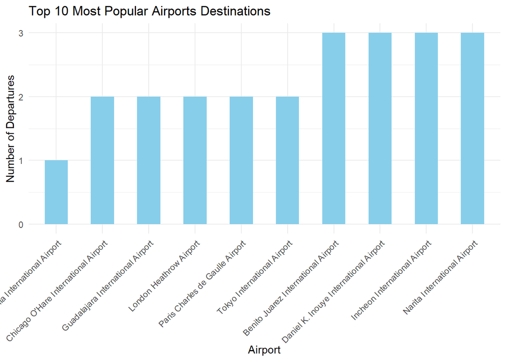

#### **What is the proportion of Domestic flights compared to International flights leaving the airport?**

To understand the distribution of flights leaving the airport, we have analysed the proportion of domestic and international flights.

Proportion of Domestic Vs International Flights

| destination | total | proportion |
| --- | --- | --- |
| Domestic | 14 | 0.3 |
| International | 33 | 0.7 |

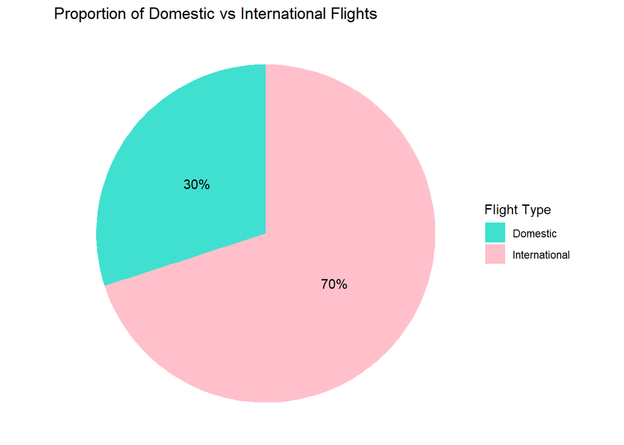

The table above shows the proportion of domestic and international flights leaving the airport. It provides insights into the balance between domestic and international air traffic.

As we can see, **30%** of the flights leaving the airport are **domestic**, while **70%** are **international**.

#### **What are the top 10 most popular airlines departing the airport?**

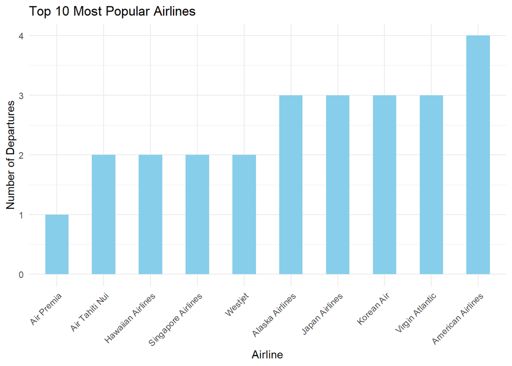

The bar chart above displays the top 10 most popular airlines based on the number of departures. It provides insights into the prominence of different airlines at Thomas Bradley, LAX.

As we can see, the most popular airline based on the number of departures is **American Airlines**, with **4** outgoing flights.

#### **What are the busiest times of day?**

To identify the most popular times of day for flights to depart, we have analyzed the dataset and categorized the departure times into hourly time slots.

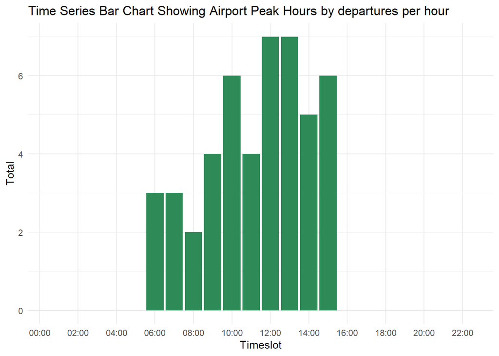

The time series bar chart above illustrates the distribution of departures per hour, highlighting the busiest periods at the airport. Each bar represents a one-hour time slot, and the height of the bar represents the total number of departures during that time slot.

#### **Delays**

Additionally, we analyzed the average delay time and the proportion of delayed flights at Thomas Bradley, LAX.

We determined the proportion of flights that experienced delays. The analysis revealed that approximately **5.4%** of flights departing from Thomas Bradley, LAX experienced some form of delay. This metric is crucial for understanding the reliability and punctuality of flight operations at the airport. It highlights the importance of implementing strategies and measures to minimize delays, enhance passenger satisfaction, and ensure smooth travel experiences.

By examining the average delay time and the proportion of delayed flights, Thomas Bradley, LAX can assess its performance in terms of timeliness and take appropriate measures to improve operational efficiency and minimize disruptions for passengers.

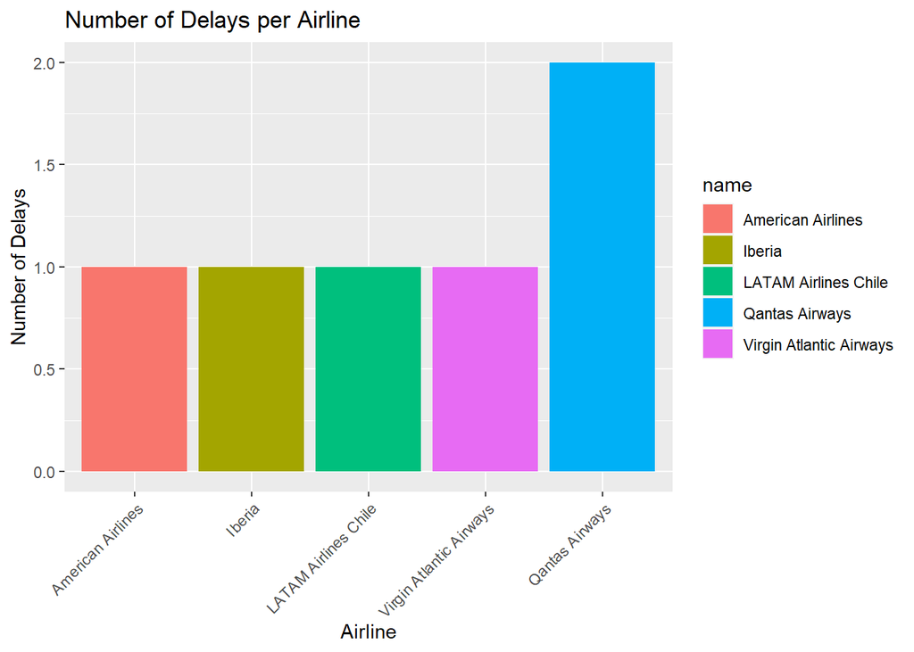

This chart shows the number of delays per airline. The x-axis represents the airlines, and the y-axis represents the number of delays. The bars represent each airline, and their heights correspond to the number of delays. The chart helps visualize which airlines have the highest number of delays. The airline with the highest number of delays is **Qantas Airways**, with **2** flights delayed.

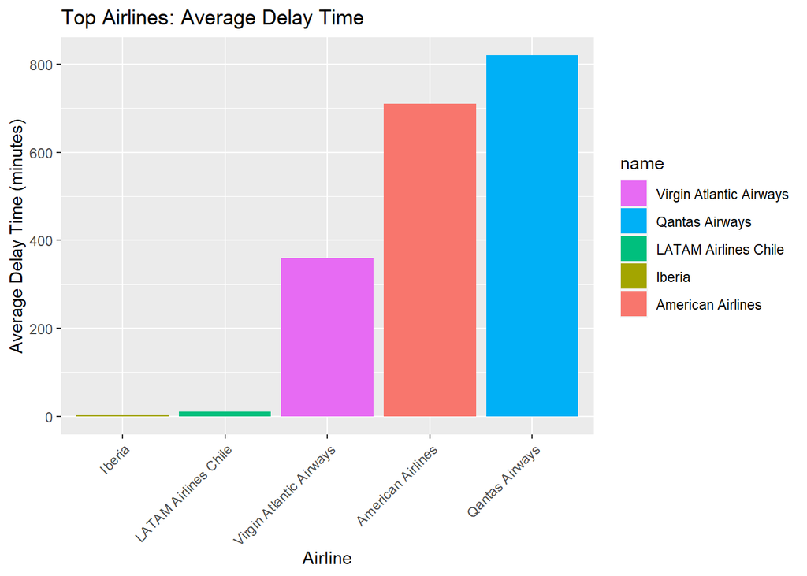

This chart displays the top airlines based on average delay time. The x-axis represents the airlines, and the y-axis represents the average delay time in minutes. The bars represent each airline, and their heights represent the average delay time. The airline with the longest average delay time is **Qantas Airways** with an average delay time of **820.5** minutes.

Highest proportions of delays per flight

| name | total_flights | num_delays | average_delay | proportion_delayed |
| --- | --- | --- | --- | --- |
| Qantas Airways | 5 | 2 | 820.5 | 0.40 |
| Iberia | 3 | 1 | 3.0 | 0.33 |
| Virgin Atlantic Airways | 6 | 1 | 359.0 | 0.17 |
| LATAM Airlines Chile | 8 | 1 | 10.0 | 0.12 |
| American Airlines | 9 | 1 | 710.0 | 0.11 |

The table presents the worst performing airlines based on the proportion of flights delayed. It includes columns for the airline name, total number of flights, number of delays, average delay time, and the proportion of flights delayed. The table helps to identify airlines with the highest proportions of delays per flight.

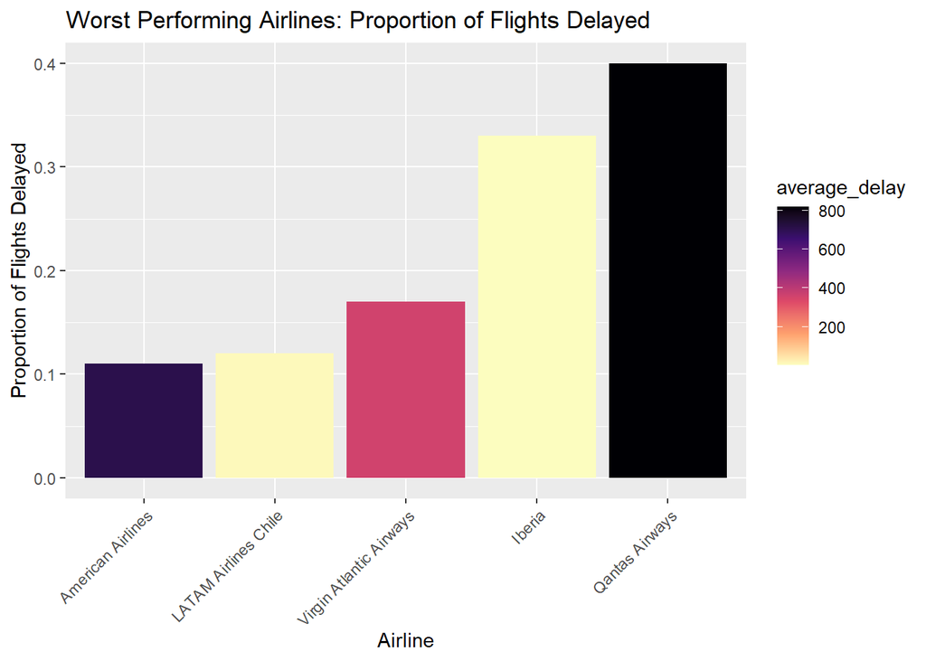

This chart shows the proportion of flights delayed for the worst performing airlines. The x-axis represents the airlines, and the y-axis represents the proportion of flights delayed. The bars represent each airline, and their lengths represent the proportion of delays. The airline with the highest proportion of flights delayed is **Qantas Airways** with a proportion of **0.4** delays per flight.

#### **Live Flight Data - proportion of flights running on time**